# project : healthcare-dataset-stroke-data

- Introduction
- laoding library
- Basic Infprmation on Data
- Data Cleaning
- Explortery Data Analysis (EDA)
- Data Cleaning

# Introduction

**A stroke is a serious life-threatening medical condition that happens when the blood supply to part of the brain is cut off.** **some Symptoms of a stroke** **The main symptoms of stroke can be remembered with the word FAST:**

**Face – the face may have dropped on 1 side, the person may not be able to smile, or their mouth or eye may have dropped.** **Arms – the person with suspected stroke may not be able to lift both arms and keep them there because of weakness or numbness in 1 arm.** **Speech – their speech may be slurred or garbled, or the person may not be able to talk at all despite appearing to be awake; they may also have problems** **understanding what you're saying to them.**

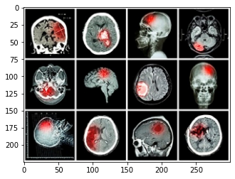

```python
import matplotlib.pyplot as plt
a=plt.imread('D:\\3.jpg')
d=plt.imread('D:\\2.jpg')
plt.imshow(a);
```

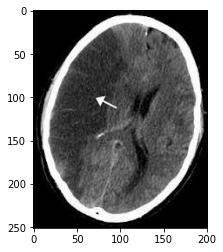

```python
plt.imshow(d);
```

# laoding library

```python
import numpy as np
import pandas as pd
import matplotlib.pyplot as plt
import seaborn as sns
%matplotlib inline
```

```python
# Use pandas libriry to raed data
# and view the frist 5 rows
df= pd.read_csv('healthcare-dataset-stroke-data.csv')
df.head()
```

|  | id | gender | age | hypertension | heart_disease | ever_married | work_type | Residence_type | avg_glucose_level | bmi | smoking_status | stroke |
| --- | --- | --- | --- | --- | --- | --- | --- | --- | --- | --- | --- | --- |
| 0 | 9046 | Male | 67.0 | 0 | 1 | Yes | Private | Urban | 228.69 | 36.6 | formerly smoked | 1 |
| 1 | 51676 | Female | 61.0 | 0 | 0 | Yes | Self-employed | Rural | 202.21 | NaN | never smoked | 1 |
| 2 | 31112 | Male | 80.0 | 0 | 1 | Yes | Private | Rural | 105.92 | 32.5 | never smoked | 1 |
| 3 | 60182 | Female | 49.0 | 0 | 0 | Yes | Private | Urban | 171.23 | 34.4 | smokes | 1 |
| 4 | 1665 | Female | 79.0 | 1 | 0 | Yes | Self-employed | Rural | 174.12 | 24.0 | never smoked | 1 |

```python
df.tail()
```

|  | id | gender | age | hypertension | heart_disease | ever_married | work_type | Residence_type | avg_glucose_level | bmi | smoking_status | stroke |
| --- | --- | --- | --- | --- | --- | --- | --- | --- | --- | --- | --- | --- |
| 5105 | 18234 | Female | 80.0 | 1 | 0 | Yes | Private | Urban | 83.75 | NaN | never smoked | 0 |
| 5106 | 44873 | Female | 81.0 | 0 | 0 | Yes | Self-employed | Urban | 125.20 | 40.0 | never smoked | 0 |
| 5107 | 19723 | Female | 35.0 | 0 | 0 | Yes | Self-employed | Rural | 82.99 | 30.6 | never smoked | 0 |
| 5108 | 37544 | Male | 51.0 | 0 | 0 | Yes | Private | Rural | 166.29 | 25.6 | formerly smoked | 0 |
| 5109 | 44679 | Female | 44.0 | 0 | 0 | Yes | Govt_job | Urban | 85.28 | 26.2 | Unknown | 0 |

```python
df.sample(5)
```

|  | id | gender | age | hypertension | heart_disease | ever_married | work_type | Residence_type | avg_glucose_level | bmi | smoking_status | stroke |
| --- | --- | --- | --- | --- | --- | --- | --- | --- | --- | --- | --- | --- |
| 2807 | 53862 | Female | 41.0 | 0 | 0 | Yes | Govt_job | Rural | 106.35 | 26.1 | never smoked | 0 |
| 1940 | 17441 | Female | 31.0 | 0 | 0 | No | Self-employed | Rural | 75.27 | 27.3 | never smoked | 0 |
| 2619 | 30824 | Male | 12.0 | 0 | 0 | No | children | Rural | 115.47 | 22.6 | Unknown | 0 |
| 3943 | 21333 | Male | 56.0 | 1 | 0 | Yes | Private | Rural | 206.66 | 21.9 | smokes | 0 |
| 1591 | 56309 | Female | 25.0 | 0 | 0 | Yes | Private | Rural | 69.24 | 26.6 | never smoked | 0 |

# Basic Infprmation on Data

```python
df.columns
```

```
Index(['id', 'gender', 'age', 'hypertension', 'heart_disease', 'ever_married',
       'work_type', 'Residence_type', 'avg_glucose_level', 'bmi',
       'smoking_status', 'stroke'],
      dtype='object')
```

```python
df.info()
```

```
<class 'pandas.core.frame.DataFrame'>
RangeIndex: 5110 entries, 0 to 5109
Data columns (total 12 columns):
 #   Column             Non-Null Count  Dtype
---  ------             --------------  -----
 0   id                 5110 non-null   int64
 1   gender             5110 non-null   object
 2   age                5110 non-null   float64
 3   hypertension       5110 non-null   int64
 4   heart_disease      5110 non-null   int64
 5   ever_married       5110 non-null   object
 6   work_type          5110 non-null   object
 7   Residence_type     5110 non-null   object
 8   avg_glucose_level  5110 non-null   float64
 9   bmi                4909 non-null   float64
 10  smoking_status     5110 non-null   object
 11  stroke             5110 non-null   int64
dtypes: float64(3), int64(4), object(5)
memory usage: 479.2+ KB
```

```python
df.shape
```

```
(5110, 12)
```

### The data consists of 5110 rows and 12 columns :

> 1-id: unique identifier

> 2-gender: "Male", "Female" or "Other"

> 3-age: age of the patient

> 4-hypertension: 0 if the patient doesn't have hypertension, 1 if the patient has hypertension

> 5-heart_disease: 0 if the patient doesn't have any heart diseases, 1 if the patient has a heart disease

> 6-ever_married: "No" or "Yes"

> 7-work_type: "children", "Govt_jov", "Never_worked", "Private" or "Self-employed"

> 8-Residence_type: "Rural" or "Urban"

> 9-avg_glucose_level: average glucose level in blood

> 10-bmi: body mass index

> 11-smoking_status: "formerly smoked", "never smoked", "smokes" or "Unknown"

> 12-stroke: 1 if the patient had a stroke or 0 if not

> Note: "Unknown" in smoking_status means that the information is unavailable for this patient.